# OSM report 2022-2023

Marissa Dyck

2024-03-25

# Before you begin

## Notes

A few notes about this script.

If you are running this with the 2022-2023 data make sure you download the whole (OSM_2022-2023 GitHub repository)[https://github.com/ACMElabUvic/OSM_2022-2023] from the ACMElabUvic GitHub. This will ensure you have all the files, data, and proper folder structure you will need to run this code and associated analyses.

Also make sure you open RStudio through the R project (OSM_2022-2023.Rproj) this will automatically set your working directory to the correct place (wherever you saved the repository) and ensure you don’t have to change the file paths for some of the data.

Lastly, if you are looking to adapt this code for a future year of data, you will want to ensure you have run the ACME_camera_script_9-2-2024.R or .Rmd with your data as there is much data formatting, cleaning, and restructuring that has to be done before this code will work.

If you have question please email the most recent author, currently

Marissa A. Dyck  
Postdoctoral research fellow  
University of Victoria  
School of Environmental Studies  
Email: marissadyck17@gmail.com

## Install packages

If you don’t already have the following packages installed, use the code below to install them.

```r
install.packages('tidyverse')
install.packages('ggpubr')
```

## Load libraries

Then load the packages to your library.

```r
library(tidyverse) # data tidying, visualization, and much more; this will load all tidyverse packages, can see complete list using tidyverse_packages()
library(ggpubr) # make modificaions to plot for publication (arrange plots)
```

# Data

## Load detection data

Read in saved and cleaned detection data from the ACME_camera_script_9-2-2024.R.

```r
# detection data
# read in saved and cleaned detection data from the ACME_camera_script_9-2-2024.R
detections <- read_csv('data/processed/OSM_2022_ind_det.csv') %>%

  # change site, species and event_id to factor
  mutate_if(is.character,
            as.factor)
```

## Data formatting

In order to get plots that have the same formatting as last years’ report we have to do a bit of data formatting. First we need to make sure we are including the same relevant species (some were ignored for last years’ report or grouped together)

Last years report had the following species

- white-tailed deer
- snowshoe hare
- black bear
- coyote
- red squirrel
- fisher
- unknown
- moose
- lynx
- spruce grouse
- red fox
- striped skunk
- ruffed grouse
- owl
- grey wolf
- domestic dog
- cougar
- raven
- other
- mule deer

And they grouped all humans except for staff as ‘Humans’. Let’s look at the species we have in this year’s data and try to format it the same way

```r
detections %>%

  # group by array and species
  group_by(array, species) %>%
  summarise(n = n()) %>%

  # have R print everything
  print(n = nrow(.))
```

```
## # A tibble: 119 × 3
## # Groups:   array [4]
##     array species                 n
##     <fct> <fct>               <int>
##   1 LU01  Beaver                  1
##   2 LU01  Black bear            380
##   3 LU01  Cougar                  7
##   4 LU01  Coyote                581
##   5 LU01  Domestic dog            6
##   6 LU01  Fisher                111
##   7 LU01  Grey jay               14
##   8 LU01  Grey wolf              21
##   9 LU01  Human                   3
##  10 LU01  Lynx                   55
##  11 LU01  Moose                  99
```

[output cut: 108 more lines]

```r
# now let's create a new data frame (tibble) to work with for the OSM figure summaries specifically

# I personally would lump all the unknown together and all the birds together but for the sake of consistency with last years' figures we will remove some entries, let's create a vector of entries to drop

species_drop <- c('Staff',
                  'Unknown deer',
                  'Unknown ungulate',
                  'Unknown canid',
                  'Unknown mustelid',
                  'Other birds')

# now we can create the new data frame with some changes consistent w/ choices made for 2021-2022
detections <- detections %>%

  # for summarizing, lets lump all the recreational humans into "Humans"
  mutate(species = recode_factor(species,
                                 "Snowmobiler" = "Human",
                                 "ATVer" = "Human",
                                 'Hunter' = 'Human')) %>%

  # remove species we don't want to plot
  filter(!species %in% species_drop)
```

We will also want to subset the data by landscape unit (LU) and generate a new data frame for each LU to use for plotting

```r
# we will also want to create a data frame for each LU to plot individually

# LU1
dets_LU1 <- detections %>%
  filter(array == 'LU01')

# LU13
dets_LU13 <- detections %>%
  filter(array == 'LU13')

# LU15
dets_LU15 <- detections %>%
  filter(array == 'LU15')

# LU21
dets_LU21 <- detections %>%
  filter(array == 'LU21')
```

## ANDREW HELP

Can you make the above code into a forloop which assigns each new data frame created from subsetting as dets_LUname?

# Detection plots

## Detection data

Now we can apply the same data formatting for each LUs’ data frame using purrr.

We want to count the number of independent detections per species per LU to use in the detection plots

```r
# apply the same formatting to each LU data frame using purrr map
detection_data <- list(dets_LU1,
                       dets_LU13,
                       dets_LU15,
                       dets_LU21) %>%

  purrr::map(
    ~.x %>%

      # group by species
      group_by(species) %>%

      # calculate a column with unique accounts of each species
      mutate(count = n_distinct(event_id)) %>%

      # keep just the columns we need
      select(species, count) %>%

      # keep only unique (distinct) rows so we should be left with one row per species, this helps with plotting later if you don't do it ggplot will try to count and plot each row it's annoying
      distinct()) %>%

  # set names of list objects
  purrr::set_names('Detections LU01',
                   'Detections LU13',
                   'Detections LU15',
                   'Detections LU21')
```

## Detection plots

Now to graph independent detections for each LU using purrr, this avoids a TON of code repetition needed to plot each one individually

We use `purrr::imap()` instead of `purrr::map()` because imap maintains the variable names in our list (e.g. Detections LU01, Detections LU13, etc.) which we can then use to title each plot.

Within `purrr::imap()` we just paste the code we would use for a single ggplot since all the graphical elements (except the title which we change with the file name [.y]) are the same

```
## $`Detections LU01`
```

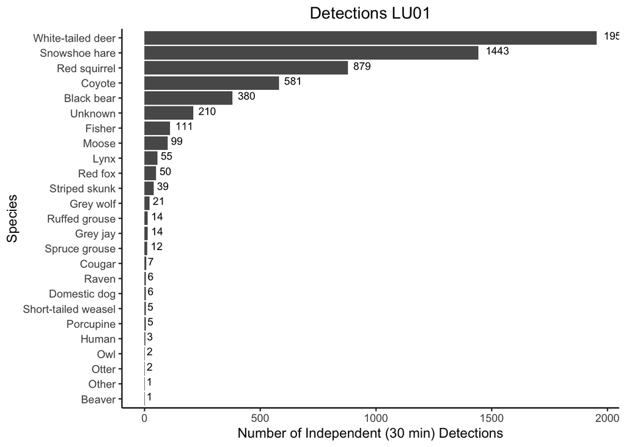

```
##
## $`Detections LU13`
```

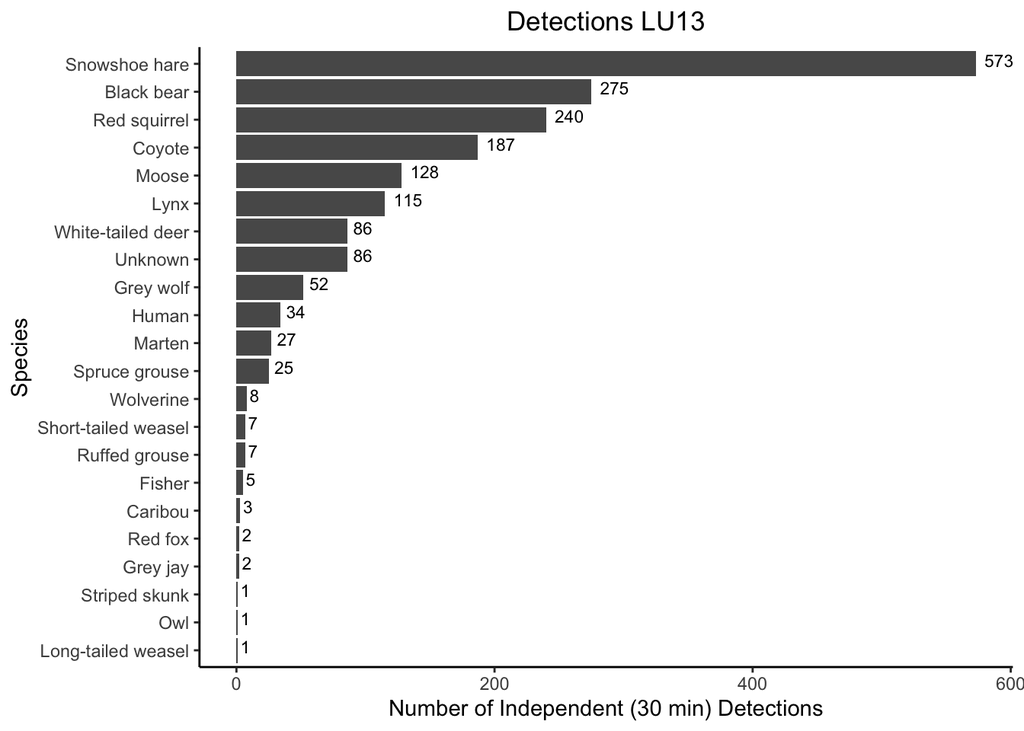

```
##
## $`Detections LU15`
```

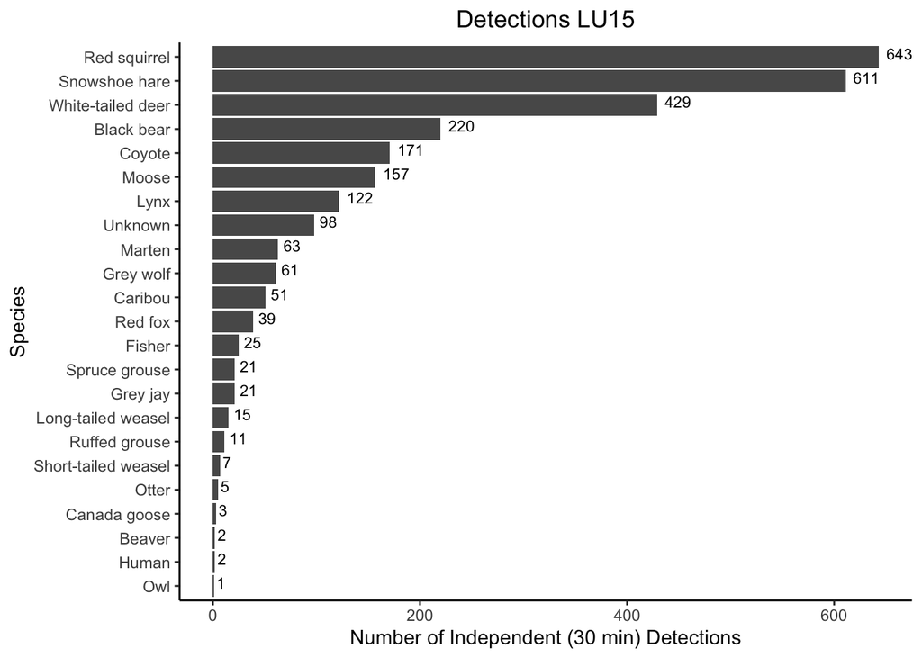

```
##
## $`Detections LU21`
```

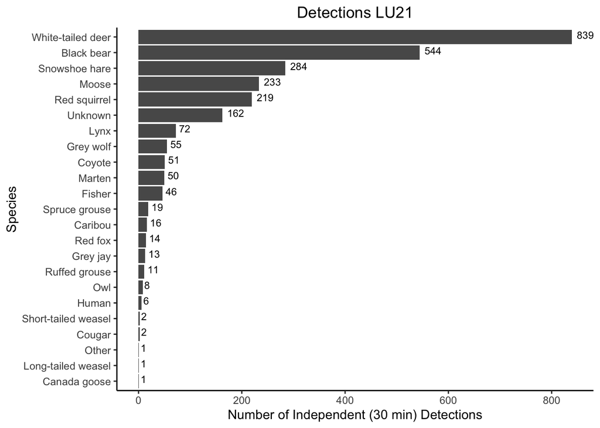

```r
# create object detection plots which uses the detection_data list (w/ all 4 LUs)
detection_plots <- detection_data %>%

  # use imap instead of map as it allows us to use .y to paste the list element names as the plot titles later
  purrr::imap(
    ~.x %>%

      # now just copy and paste the ggplot code for the detection graphs
      ggplot(.,
             aes(x = reorder(species, count), y = count)) +

      # plot as bar graph using geom_col so we don't have to provide a y aesthetic
      geom_col() +

      # switch the x and y axis
      coord_flip() +

      # add the number of detections at the end of each bar
      geom_text(aes(label = count),
                color = "black",
                size = 3,
                hjust = -0.3,
                vjust = 0.2) +

      # label x and y axis with informative titles
      labs(x = 'Species',
           y = 'Number of Independent (30 min) Detections') +

      # add title to plot with LU name the .y will take the name of whatever you named each list element in the detection_data list, so make sure this name is what you want on the ggtitle
      ggtitle(.y) +

      # set the theme
      theme_classic() +
      theme(plot.title = element_text(hjust = 0.5)))

# view plots, this will print each in it's own window so you have to scroll back in the plot viewer pane to look at each one
detection_plots
```

## Save detection plots

Now we want to save these plots in case we need each individual one (we will combine the detection and naive occ plots into a single figure for each LU later and use those for the OSM report, but we may want these standalone plots later so let’s save them while they are here).

We can save all the plots from the purrr iteration above using `purrr::imap`. imap is used instead of map because it allows us to retain the list object names (plot names) to paste as the file name with the .y command. > IMPORTANT if you are using this code for a future github repo, DO NOT use .tiff as the file extension. This will cause issues when trying to push any changes to the github repo as the files are too large to meet githubs requirements

```r
# save plots only use if needed
purrr::imap(
  detection_plots,
  ~ggsave(.x,
             file = paste0("figures/",
                           .y,
                           '.jpg'), # avoid using .tiff extension in the github repo, those files are too large to push to origin
          dpi = 600,
          width = 11,
          height = 9,
          units = 'in'))
```

```
## $`Detections LU01`
## [1] "figures/Detections LU01.jpg"
##
## $`Detections LU13`
## [1] "figures/Detections LU13.jpg"
##
## $`Detections LU15`
## [1] "figures/Detections LU15.jpg"
##
## $`Detections LU21`
## [1] "figures/Detections LU21.jpg"
```

# Naive occupancy

## Data

We also need to alter the detection data a bit to use for naive occupancy plots.

We will use the individual LU detection data like we did before and use `purrr::map()` to apply the dame data formatting to all 4 data frames.

Here we want to calculate the total number of sites in each LU, the number of sites each species was detected at in each LU and then use both those numbers to calculate naive occupancy for each species in each LU

```r
# First we need to alter the data frame a bit for these plots, let's create a data frame for each LU (I couldn't figure out how to do this without assigning individual data frames for each UGH)


# apply the same formatting to each data frame using purrr
occupancy_data <- list(dets_LU1,
                       dets_LU13,
                       dets_LU15,
                       dets_LU21) %>%

  purrr::map(
    ~.x %>%

      # calculate the total number of sites for each LU
      mutate(total_sites = n_distinct(site)) %>%

      # group by species to calculate the number of sites each spp occurred at
      group_by(species) %>%

      # add columns to count the number of sites each spp occurred at and then the naive occupancy
  reframe(count = n_distinct(site),
          naive_occ = count/total_sites,
          ind_det = n_distinct(event_id)) %>%

    # keep just the columns we need
  select(species, naive_occ, ind_det) %>%

    # keep only unique (distinct) rows so we should be left with one row per species, this helps with plotting
  distinct()) %>%

  purrr::set_names('Naive Occupancy LU01',
                   'Naive Occupancy LU13',
                   'Naive Occupancy LU15',
                   'Naive Occupancy LU21')
```

## Occupancy plots

Now we can graph naive occupancy for each LU using purrr, and as with the detection plots this saves a massive amount of coding using purrr to run an iteration on the data files and produce four plots at once instead of copying and pasting code for each individually

```
## $`Naive Occupancy LU01`
```

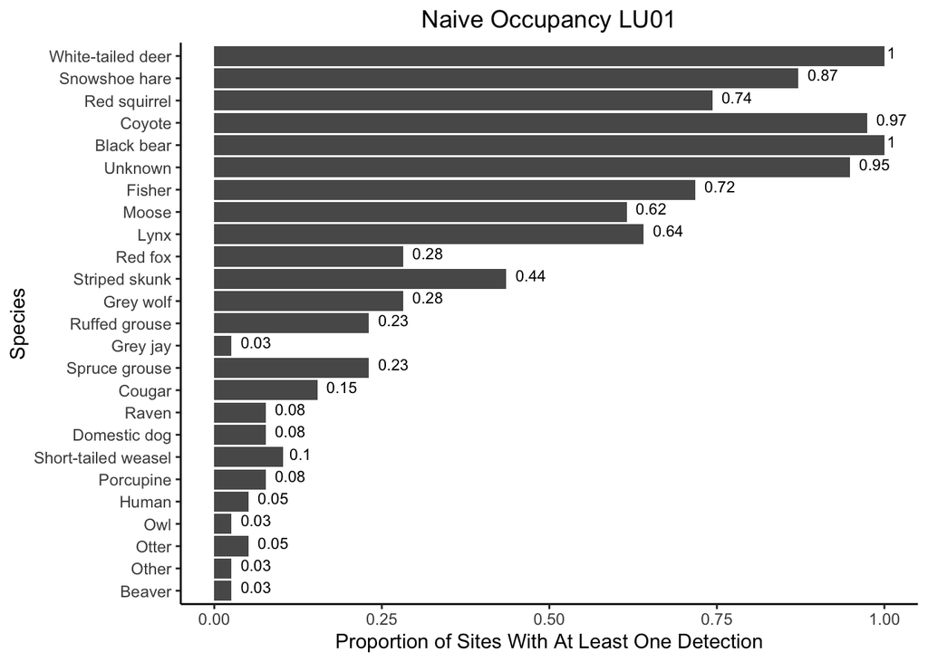

```
##
## $`Naive Occupancy LU13`
```

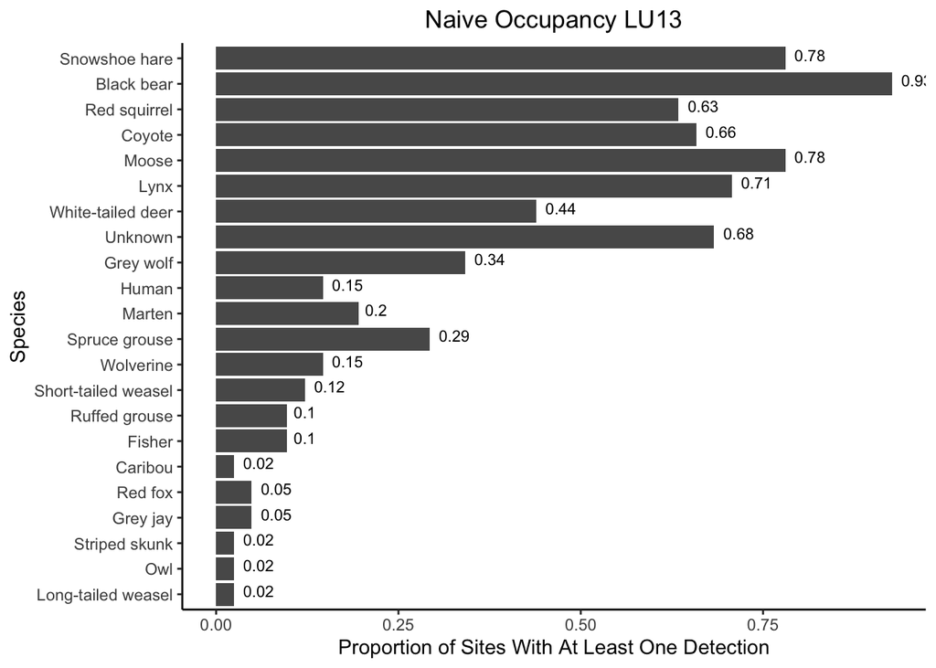

```
##
## $`Naive Occupancy LU15`
```

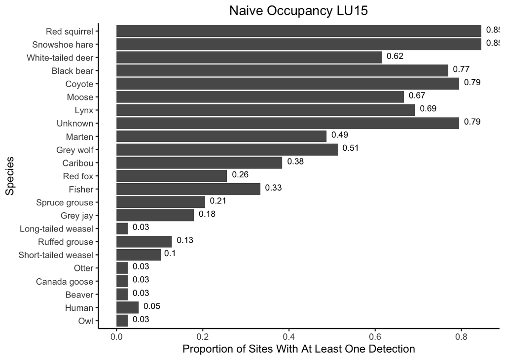

```
##
## $`Naive Occupancy LU21`
```

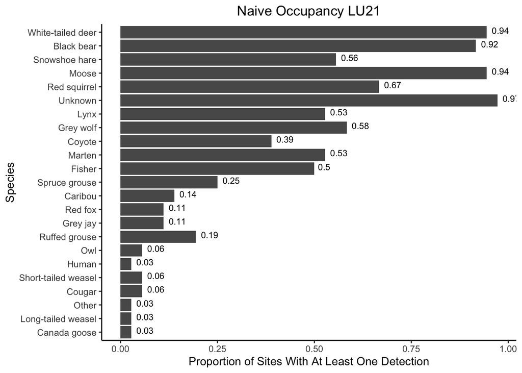

```r
# create object occupancy_plots which uses the occupancy_data list (w/ all 4 LUs)
occupancy_plots <- occupancy_data %>%

  # use imap instead of map as it allows us to use .y to paste the list element names as the plot titles later
  purrr::imap(
    ~.x %>%

      # now just copy and paste the ggplot code for the occupancy graphs
      ggplot(.,
             aes(x = fct_reorder(species,
                                 ind_det), # this reorders the species so they match the order of the detection plot which makes it better for viewing when the plots are arranged together in 1 figure for each LU
                 y = naive_occ)) +

      # plot as bars using geom_col() which uses stat = 'identity', instead of geom_bar() which will count the rows in each group and plot that instead of naive occ
      geom_col() +

      # flip x and y axis
      coord_flip() +

      # add text to end of bars that provides naive occ value
      geom_text(aes(label = round(naive_occ, 2)),
                size = 3,
                hjust = -0.3,
                vjust = 0.2) +

      # relabel x and y axis and title
      labs(x = 'Species',
           y = 'Proportion of Sites With At Least One Detection') +

      # set plot title using .y (name of list object)
      ggtitle(.y) +

      # set. theme elements
      theme_classic()+
      theme(plot.title = element_text(hjust = 0.5)))

# view plots
occupancy_plots
```

## Save occupancy plots

As with the detection plots, we might want these individual plots later for something so we can use `purrr::imap()` to save them to the figures folder

Again avoid using the .tiff extension in github

```r
# save plots
purrr::imap(
  occupancy_plots,
  ~ggsave(.x,
          file = paste0("figures/",
                        .y,
                        '.jpg'), # avoid using .tiff extension in the github repo, those files are too large to push to origin
          dpi = 600,
          width = 11,
          height = 9,
          units = 'in'))
```

```
## $`Naive Occupancy LU01`
## [1] "figures/Naive Occupancy LU01.jpg"
##
## $`Naive Occupancy LU13`
## [1] "figures/Naive Occupancy LU13.jpg"
##
## $`Naive Occupancy LU15`
## [1] "figures/Naive Occupancy LU15.jpg"
##
## $`Naive Occupancy LU21`
## [1] "figures/Naive Occupancy LU21.jpg"
```

# Final combined plots for report

The previous year’s report had a figure for each LU with the detections plot on the top and the occupancy plot on the bottom so we will recreate these for this year using `ggarrange()`.

Unfortunately I could not figure out how to do this in purrr to reduce coding but luckily it isn’t too much repitition

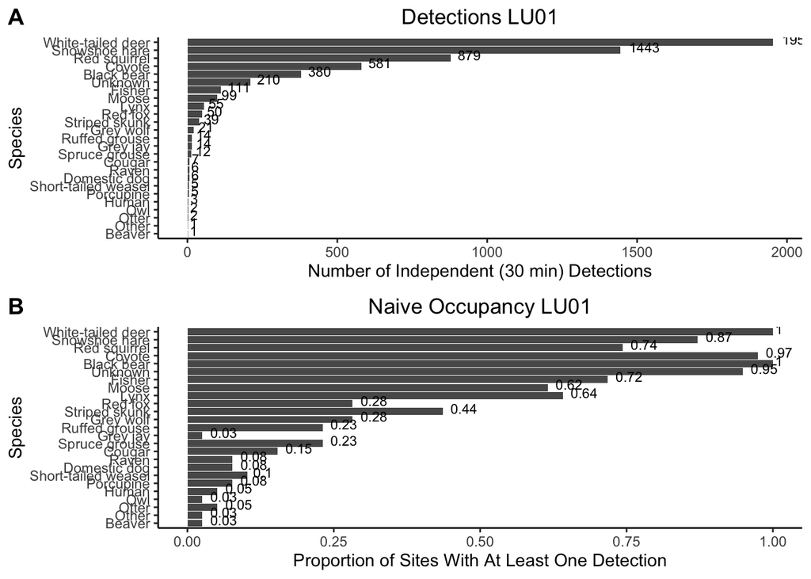

```r
# not sure I know how to do the following section in purrr just yet, but we've saved a ton of coding so far and it doesn't take much to arrange each of these individually

# LU1

# arrange the plots so each LU has a figure with detections on top and naive occ on bottom
LU1_det_occ_plots <- ggarrange(detection_plots$`Detections LU01`, occupancy_plots$`Naive Occupancy LU01`,
                               labels = c("A", "B"),
                               nrow = 2)

# view plot
LU1_det_occ_plots
```

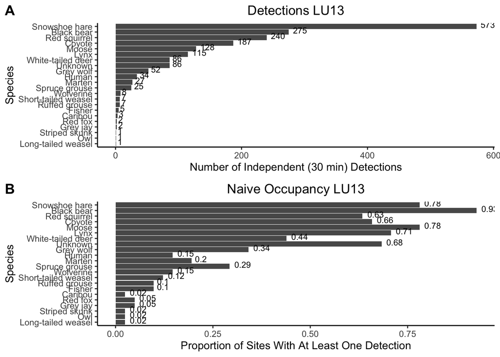

```r
# LU13

# arrange the plots so each LU has a figure with detections on top and naive occ on bottom
LU13_det_occ_plots <- ggarrange(detection_plots$`Detections LU13`, occupancy_plots$`Naive Occupancy LU13`,
                               labels = c("A", "B"),
                               nrow = 2)

# view plot
LU13_det_occ_plots
```

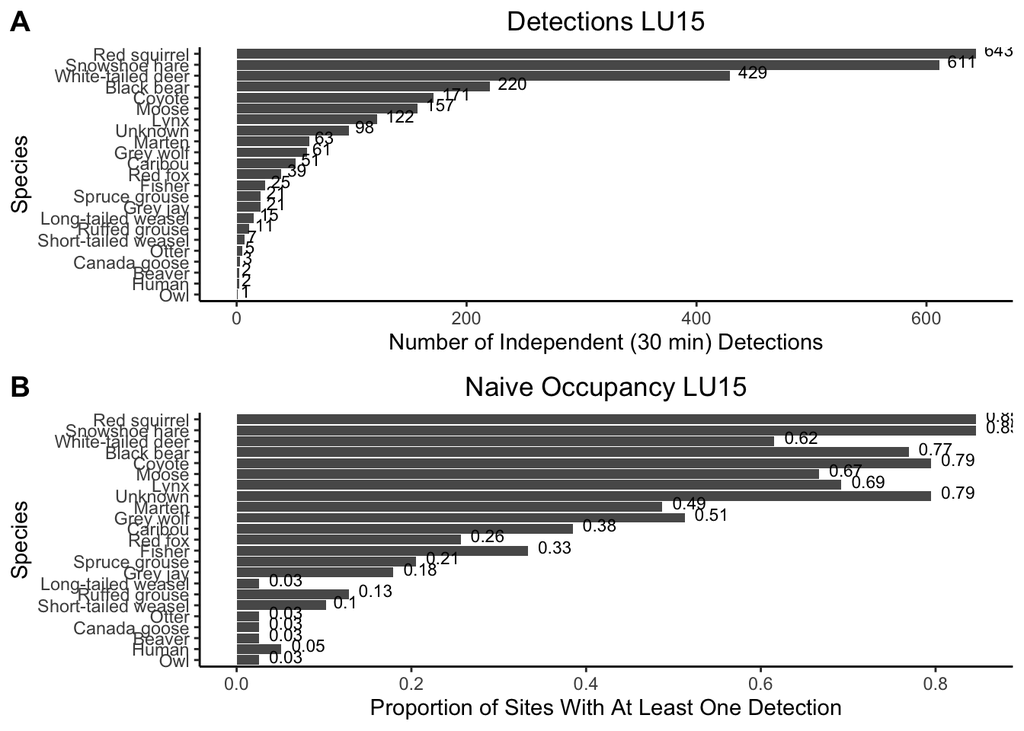

```r
# LU15

# arrange the plots so each LU has a figure with detections on top and naive occ on bottom
LU15_det_occ_plots <- ggarrange(detection_plots$`Detections LU15`, occupancy_plots$`Naive Occupancy LU15`,
                                labels = c("A", "B"),
                                nrow = 2)

# view plot
LU15_det_occ_plots
```

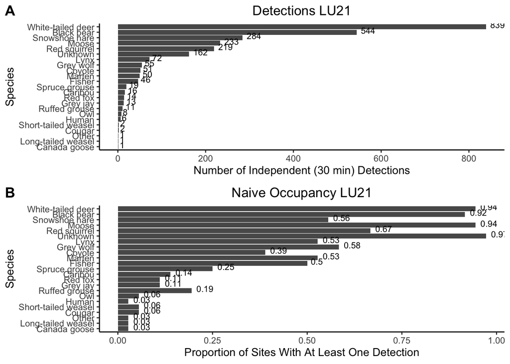

```r
# LU21

# arrange the plots so each LU has a figure with detections on top and naive occ on bottom
LU21_det_occ_plots <- ggarrange(detection_plots$`Detections LU21`, occupancy_plots$`Naive Occupancy LU21`,
                                labels = c("A", "B"),
                                nrow = 2)

# view plot
LU21_det_occ_plots
```

We can however, save all the figures again using purrr

```r
# save all figures at once using purrr
final_det_occ_plots <- list(LU1_det_occ_plots,
                            LU13_det_occ_plots,
                            LU15_det_occ_plots,
                            LU21_det_occ_plots) %>%


  purrr::set_names('LU01_det_occ_plots',
                   'LU13_det_occ_plots',
                   'LU15_det_occ_plots',
                   'LU21_det_occ_plots') %>%

  purrr::imap(
    ~ggsave(.x,
            file = paste0("figures/",
                          .y,
                          '.jpg'), # avoid using .tiff extension in the github repo, those files are too large to push to origin
            dpi = 600,
            width = 12,
            height = 15,
            units = 'in'))
```

# Analysis

## Read in data

We need the proportional binomial data and the covariate data (from the ACME_camera_script_9-2-2024.R or .Rmd), let’s read those in now and check the structure of each

```r
# response metric (proportional detections from the from the ACME_camera_script_9-2-2024.R or .Rmd)
prop_detections <- read_csv('data/processed/OSM_2022_proportional_detections.csv')
# check variable structure
str(prop_detections)
```

```
## spc_tbl_ [152 × 23] (S3: spec_tbl_df/tbl_df/tbl/data.frame)
##  $ site                    : chr [1:152] "LU01_06" "LU01_10" "LU01_11" "LU01_13" ...
##  $ black_bear              : num [1:152] 7 3 4 7 8 9 4 5 7 7 ...
##  $ coyote                  : num [1:152] 4 4 8 10 11 9 11 0 9 4 ...
##  $ fisher                  : num [1:152] 5 3 3 3 2 1 1 1 0 3 ...
##  $ moose                   : num [1:152] 3 2 5 9 1 0 2 4 1 0 ...
##  $ white-tailed_deer       : num [1:152] 12 5 12 12 13 14 15 9 12 10 ...
##  $ cougar                  : num [1:152] 0 0 1 0 1 0 0 0 0 0 ...
##  $ grey_wolf               : num [1:152] 0 0 2 0 0 0 1 0 0 0 ...
##  $ lynx                    : num [1:152] 0 0 1 0 1 1 0 0 0 2 ...
##  $ red_fox                 : num [1:152] 0 0 2 0 0 0 0 0 4 0 ...
##  $ wolverine               : num [1:152] 0 0 0 0 0 0 0 0 0 0 ...
##  $ caribou                 : num [1:152] 0 0 0 0 0 0 0 0 0 0 ...
##  $ absent_black_bear       : num [1:152] 5 3 8 5 4 3 8 7 5 5 ...
##  $ absent_coyote           : num [1:152] 10 1 6 5 3 5 4 15 6 11 ...
##  $ absent_fisher           : num [1:152] 9 2 11 12 12 13 14 14 15 12 ...
##  $ absent_moose            : num [1:152] 11 3 9 6 13 14 13 11 14 15 ...
##  $ absent_white-tailed_deer: num [1:152] 2 0 2 3 1 0 0 6 3 5 ...
##  $ absent_cougar           : num [1:152] 14 5 13 15 13 14 15 15 15 15 ...
##  $ absent_grey_wolf        : num [1:152] 14 5 12 15 14 14 14 15 15 15 ...
##  $ absent_lynx             : num [1:152] 14 5 13 15 13 13 15 15 15 13 ...
##  $ absent_red_fox          : num [1:152] 14 5 12 15 14 14 15 15 11 15 ...
##  $ absent_wolverine        : num [1:152] 14 5 14 15 14 14 15 15 15 15 ...
##  $ absent_caribou          : num [1:152] 14 5 14 15 14 14 15 15 15 15 ...
##  - attr(*, "spec")=
##   .. cols(
##   ..   site = col_character(),
##   ..   black_bear = col_double(),
##   ..   coyote = col_double(),
##   ..   fisher = col_double(),
##   ..   moose = col_double(),
##   ..   `white-tailed_deer` = col_double(),
##   ..   cougar = col_double(),
##   ..   grey_wolf = col_double(),
##   ..   lynx = col_double(),
##   ..   red_fox = col_double(),
##   ..   wolverine = col_double(),
##   ..   caribou = col_double(),
##   ..   absent_black_bear = col_double(),
##   ..   absent_coyote = col_double(),
##   ..   absent_fisher = col_double(),
##   ..   absent_moose = col_double(),
##   ..   `absent_white-tailed_deer` = col_double(),
##   ..   absent_cougar = col_double(),
##   ..   absent_grey_wolf = col_double(),
##   ..   absent_lynx = col_double(),
##   ..   absent_red_fox = col_double(),
##   ..   absent_wolverine = col_double(),
##   ..   absent_caribou = col_double()
##   .. )
##  - attr(*, "problems")=<externalptr>
```

```r
# model covariates (merged HFI and VEG data from the ACME_camera_script_9-2-2024.R or .Rmd)
covariates <- read_csv('data/processed/OSM_2022_covariates.csv',

                       # set the column types to read in correctly
                       col_types = cols(site = col_factor(),
                                        buff_dist = col_factor(),
                                        .default = col_number()))

# check variable structure
str(covariates)
```

```
## spc_tbl_ [3,100 × 74] (S3: spec_tbl_df/tbl_df/tbl/data.frame)
##  $ site                        : Factor w/ 155 levels "LU13_18","LU13_15",..: 1 2 3 4 5 6 7 8 9 10 ...
##  $ buff_dist                   : Factor w/ 20 levels "250","500","750",..: 1 1 1 1 1 1 1 1 1 1 ...
##  $ harvest_area                : num [1:3100] 0 0 NA 0 0 0 0 0 0 0 ...
##  $ crop                        : num [1:3100] 0 0 NA 0 0 0 0 0 0 0 ...
##  $ well_aband                  : num [1:3100] 0 0 NA 0 0 0 0 0 0 0 ...
##  $ well_oil                    : num [1:3100] 0 0 NA 0 0 0 0 0 0 0 ...
##  $ trail                       : num [1:3100] 0 0 NA 0.5 0 ...
##  $ harvest_area_white_zone     : num [1:3100] 0 0 NA 0 0 0 0 0 0 0 ...
##  $ conventional_seismic        : num [1:3100] 0.5 0.5 NA 0.5 1 ...
##  $ pipeline                    : num [1:3100] 0 0.5 NA 0 0 0 0.5 0 0 0 ...
##  $ tame_pasture                : num [1:3100] 0 0 NA 0 0 0 0 0 0 0 ...
##  $ rough_pasture               : num [1:3100] 0 0 NA 0 0 0 0 0 0 0 ...
##  $ rural_residence             : num [1:3100] 0 0 NA 0 0 0 0 0 0 0 ...
##  $ transmission_line           : num [1:3100] 0 0 NA 0 0 0 0 0 0 0 ...
##  $ well_gas                    : num [1:3100] 0 0 NA 0 0 0 0 0 0 0 ...
##  $ misc_oil_gas_facility       : num [1:3100] 0 0 NA 0 0 0 0 0 0 0 ...
##  $ clearing_unknown            : num [1:3100] 0 0 NA 0 0 0 0 0 0 0 ...
##  $ vegetated_edge_roads        : num [1:3100] 0 0 NA 0 0 0 0 0 0 0 ...
##  $ road_unimproved             : num [1:3100] 0 0 NA 0 0 0 0 0 0 0 ...
##  $ road_gravel_1l              : num [1:3100] 0 0 NA 0 0 0 0 0 0 0 ...
##  $ road_gravel_2l              : num [1:3100] 0 0 NA 0 0 0 0 0 0 0 ...
##  $ truck_trail                 : num [1:3100] 0.5 0 NA 0 0 0 0 0 0 0 ...
##  $ borrowpits                  : num [1:3100] 0 0 NA 0 0 0 0 0 0 0 ...
##  $ sump                        : num [1:3100] 0 0 NA 0 0 0 0 0 0 0 ...
##  $ borrowpit_wet               : num [1:3100] 0 0 NA 0 0 0 0 0 0 0 ...
##  $ cultivation_abandoned       : num [1:3100] 0 0 NA 0 0 0 0 0 0 0 ...
##  $ urban_residence             : num [1:3100] 0 0 NA 0 0 0 0 0 0 0 ...
##  $ country_residence           : num [1:3100] 0 0 NA 0 0 0 0 0 0 0 ...
##  $ recreation                  : num [1:3100] 0 0 NA 0 0 0 0 0 0 0 ...
##  $ well_other                  : num [1:3100] 0 0 NA 0 0 0 0 0 0 0 ...
##  $ well_bitumen                : num [1:3100] 0 0 NA 0 0 0 0 0 0 0 ...
##  $ well_cased                  : num [1:3100] 0 0 NA 0 0 0 0 0 0 0 ...
##  $ road_paved_undiv_2l         : num [1:3100] 0 0 NA 0 0 0 0 0 0 0 ...
##  $ road_unclassified           : num [1:3100] 0 0 NA 0 0 0 0 0 0 0 ...
##  $ runway                      : num [1:3100] 0 0 NA 0 0 0 0 0 0 0 ...
##  $ clearing_wellpad_unconfirmed: num [1:3100] 0 0 NA 0 0 0 0 0 0 0 ...
##  $ facility_unknown            : num [1:3100] 0 0 NA 0 0 0 0 0 0 0 ...
##  $ borrowpit_dry               : num [1:3100] 0 0 NA 0 0 0 0 0 0 0 ...
##  $ grvl_sand_pit               : num [1:3100] 0 0 NA 0 0 0 0 0 0 0 ...
```

[output cut: 99 more lines]

```
##   ..   campground = col_number(),
##   ..   canal = col_number(),
##   ..   camp_industrial = col_number(),
##   ..   rlwy_sgl_track = col_number(),
##   ..   lc_class20 = col_number(),
##   ..   lc_class33 = col_number(),
##   ..   lc_class34 = col_number(),
##   ..   lc_class50 = col_number(),
##   ..   lc_class110 = col_number(),
##   ..   lc_class120 = col_number(),
##   ..   lc_class210 = col_number(),
##   ..   lc_class220 = col_number(),
##   ..   lc_class230 = col_number()
##   .. )
##  - attr(*, "problems")=<externalptr>
```

## Format covariates

There are too many covariates to include in the models individually and many of them describe similar HFI features. We can use the info from the README file in this repository which includes detailed descriptions from the [ABMI human footprints wall to wall data download website for Year 2021](https://abmi.ca/home/data-analytics/da-top/da-product-overview/Human-Footprint-Products/HF-inventory.html) **OR** in the relevant_literature folder of this repository (HFI_2021_v1_0_Metadata_Final.pdf).

> the current version of this code for the purposes of the 2022-2023 report used a merged dataset from 2021-2022 and 2022-2023 data, howver each year of data the variables were extracted slightly differenty from GIS so final version of this code will include a different formatting process which will likely occur in the ACME_camera_script_9-2-2024.R or .Rmd

```r
# reorder colnames alphabetically to view easier
covariates_ordered <- covariates %>%

  select(order(colnames(.)))


covaraites_grouped <- covariates %>%

  mutate(borrowpits = rowSums(across(contains('borrowpit'))),
         inustrial_sites = camp_industrial + oil_gas_plant + open_pit_mine +
           rowSums(across(contains('facility'))),
         seismic_lines = rowSums(across(contains('seismic'))),
         wellsites = rowSums(across(contains('well'))),
         roads =  rowSums(across(contains('road'))),
         havest_areas = rowSums(across(contains('harvest'))),
         trails = rowSums(across(contains('trail'))),
         residences = rowSums(across(contains('residence'))),
         pasture = rowSums(across(contains('pasture'))),
         other_transportation_features = runway + airp_runway + rlwy_sgl_track + vegetated_edge_railways,
         crops = crop + fruit_vegetables + cultivation_abandoned,
         water = lagoon + reservoir + dugout + canal,
         .keep = 'unused') %>%

  # remove features we don't need
  select(!c(recreation,
            clearing_unknown,
            cfo,
            grvl_sand_pit,
            transfer_station,
            campground,
            surrounding_veg,
            urban_industrial,
            landfill,
            sump,
            water,
            crops,
            other_transportation_features,
            pasture,
            residences
            ))

# see what's left
names(covaraites_grouped)
```

```
##  [1] "site"              "buff_dist"         "pipeline"
##  [4] "transmission_line" "borrowpits"        "lc_class20"
##  [7] "lc_class33"        "lc_class34"        "lc_class50"
## [10] "lc_class110"       "lc_class120"       "lc_class210"
## [13] "lc_class220"       "lc_class230"       "inustrial_sites"
## [16] "seismic_lines"     "wellsites"         "roads"
## [19] "havest_areas"      "trails"
```

```r
# subset the data by buffer width, would like Andrew to make this into a forloop eventually
```